# Practical Machine Learning: Assignment

2015-04-25

# Introduction

This assignment uses the data from Human Activity Recognition [1] project and builds a predictive model to predict activity quality from activity monitors. The classe variable indicates the activity quality.

## Prepare Libraries

Load the required libraries

```r
library(ggplot2)
library(lattice)
library(rpart)        # decision tree
library(caret)        # caret package
library(corrplot)     # correlation matrix plot
library(randomForest) # random forest
set.seed(3517)
```

## Load training data

Read the training data and replace the white space and #DIV/0! with “NA” for missing values.

```r
MyData=read.csv("pml-training.csv",header=T,na.strings=c(""," ","#DIV/0!"));
```

## Data Cleaning

Remove the columns with large number of missing values (such as NA values) since these columns will not contribute to the prediction.

The user_name is removed because it is assumed that the prediction model should be subject independent.

The column 160 (classe) is response/output (activity quality class label).

```r
clean_data=MyData[,c(8:11,37:49,60:68,84:86,102,113:124,140,151:160)]
dim(clean_data)
```

```
## [1] 19622    53
```

## Feature Selection

Calculate the correlation between predictors.

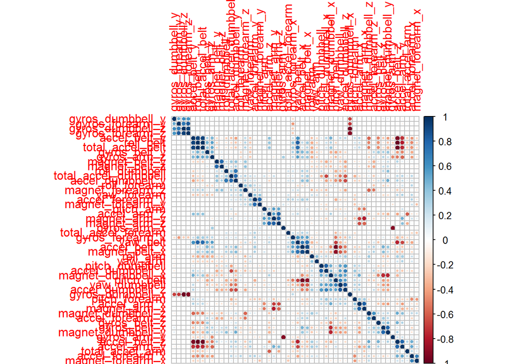

```r
# center and scale all the features but the response (last)
clean_data_scaled=scale(clean_data[1:ncol(clean_data)-1],center=TRUE,scale=TRUE)
# compute the correlation matrix
corMat = cor(clean_data_scaled)
# visualize the matrix, clustering features by correlation index.
corrplot(corMat, order = "hclust")
```

Find the indices of predictors with more than 0.7 correlation.

```r
# Apply correlation filter at 0.70
highlyCor = findCorrelation(corMat, 0.70)
# Following predictors are higly correlated
highlyCor
```

```
##  [1] 10  1  9 22  4  3 36  8  2 37 35 38 21 34 23 25 12 48 19 46 45 31
```

Filter highly correlated predictors to reduce the number of predictors

```r
clean_data_filtered=clean_data[,-highlyCor]
dim(clean_data); dim(clean_data_filtered)
```

```
## [1] 19622    53
```

```
## [1] 19622    31
```

This step reduces the number of predictors from 53 to 31

## Prepare trainig and test sets

70% of data is used for training and 30% of data is used for testing purposes.

```r
inTrain=createDataPartition(clean_data_filtered$classe,p=0.7,list=FALSE)
training=clean_data_filtered[inTrain,]
testing=clean_data_filtered[-inTrain,]
dim(training); dim(testing)
```

```
## [1] 13737    31
```

```
## [1] 5885   31
```

## Model fitting

First, try to fit decision tree with 4 fold cross validation to find the best model;

```r
modFit=train(classe ~.,method="rpart",data=training,trControl=trainControl(method="cv",number=4))
confusionMatrix(predict(modFit,training),training$classe)
```

```
## Confusion Matrix and Statistics
##
##           Reference
## Prediction    A    B    C    D    E
##          A 3275  928 1048  553  412
##          B  160 1010  110  357  501
##          C  248  568 1132  464  484
##          D  215  103   98  579   85
##          E    8   49    8  299 1043
##
## Overall Statistics
##
##                Accuracy : 0.5124
##                  95% CI : (0.504, 0.5208)
##     No Information Rate : 0.2843
##     P-Value [Acc > NIR] : < 2.2e-16
##
##                   Kappa : 0.369
##  Mcnemar's Test P-Value : < 2.2e-16
##
## Statistics by Class:
##
##                      Class: A Class: B Class: C Class: D Class: E
## Sensitivity            0.8385  0.37998  0.47245  0.25710  0.41307
## Specificity            0.7008  0.89819  0.84446  0.95638  0.96753
## Pos Pred Value         0.5269  0.47240  0.39088  0.53611  0.74129
## Neg Pred Value         0.9161  0.85792  0.88341  0.86782  0.87981
## Prevalence             0.2843  0.19349  0.17442  0.16394  0.18381
## Detection Rate         0.2384  0.07352  0.08241  0.04215  0.07593
## Detection Prevalence   0.4525  0.15564  0.21082  0.07862  0.10242
## Balanced Accuracy      0.7696  0.63909  0.65846  0.60674  0.69030
```

Since the prediction accuracy of training set is barely over 50%, try to fit random forest with 4 fold cross validation to find the best model by using the training data;

```r
modFit2=train(classe ~.,method="rf",data=training,trControl=trainControl(method="cv",number=4))
#modFit2=train(classe ~.,method="rf",data=training)
confusionMatrix(predict(modFit2,training),training$classe)
```

```
## Confusion Matrix and Statistics
##
##           Reference
## Prediction    A    B    C    D    E
##          A 3906    0    0    0    0
##          B    0 2658    0    0    0
##          C    0    0 2396    0    0
##          D    0    0    0 2252    0
##          E    0    0    0    0 2525
##
## Overall Statistics
##
##                Accuracy : 1
##                  95% CI : (0.9997, 1)
##     No Information Rate : 0.2843
##     P-Value [Acc > NIR] : < 2.2e-16
##
##                   Kappa : 1
##  Mcnemar's Test P-Value : NA
##
## Statistics by Class:
##
##                      Class: A Class: B Class: C Class: D Class: E
## Sensitivity            1.0000   1.0000   1.0000   1.0000   1.0000
## Specificity            1.0000   1.0000   1.0000   1.0000   1.0000
## Pos Pred Value         1.0000   1.0000   1.0000   1.0000   1.0000
## Neg Pred Value         1.0000   1.0000   1.0000   1.0000   1.0000
## Prevalence             0.2843   0.1935   0.1744   0.1639   0.1838
## Detection Rate         0.2843   0.1935   0.1744   0.1639   0.1838
## Detection Prevalence   0.2843   0.1935   0.1744   0.1639   0.1838
## Balanced Accuracy      1.0000   1.0000   1.0000   1.0000   1.0000
```

The OOB error[3] in final model gives an unbiased estimate of the test set error;

```r
modFit2$finalModel
```

```
##
## Call:
##  randomForest(x = x, y = y, mtry = param$mtry)
##                Type of random forest: classification
##                      Number of trees: 500
## No. of variables tried at each split: 2
##
##         OOB estimate of  error rate: 1.18%
## Confusion matrix:
##      A    B    C    D    E class.error
## A 3898    5    0    2    1 0.002048131
## B   28 2618   11    0    1 0.015048909
## C    1   29 2353   12    1 0.017946578
## D    0    0   59 2189    4 0.027975133
## E    0    0    0    8 2517 0.003168317
```

## Out of sample error

Used the testing data to estimate the out of sample error rate since the testing data is not used during the training;

```r
cm=confusionMatrix(predict(modFit2,testing),testing$classe)
print(cm)
```

```
## Confusion Matrix and Statistics
##
##           Reference
## Prediction    A    B    C    D    E
##          A 1672   20    0    0    0
##          B    2 1112   19    0    0
##          C    0    6 1004   30    0
##          D    0    0    3  934    3
##          E    0    1    0    0 1079
##
## Overall Statistics
##
##                Accuracy : 0.9857
##                  95% CI : (0.9824, 0.9886)
##     No Information Rate : 0.2845
##     P-Value [Acc > NIR] : < 2.2e-16
##
##                   Kappa : 0.9819
##  Mcnemar's Test P-Value : NA
##
## Statistics by Class:
##
##                      Class: A Class: B Class: C Class: D Class: E
## Sensitivity            0.9988   0.9763   0.9786   0.9689   0.9972
## Specificity            0.9953   0.9956   0.9926   0.9988   0.9998
## Pos Pred Value         0.9882   0.9815   0.9654   0.9936   0.9991
## Neg Pred Value         0.9995   0.9943   0.9955   0.9939   0.9994
## Prevalence             0.2845   0.1935   0.1743   0.1638   0.1839
## Detection Rate         0.2841   0.1890   0.1706   0.1587   0.1833
## Detection Prevalence   0.2875   0.1925   0.1767   0.1597   0.1835
## Balanced Accuracy      0.9970   0.9859   0.9856   0.9838   0.9985
```

## Conclusion

In this assignment, the given data is cleaned by removing predictors with large number of missing values, and predictors that are highly correlated (>0.7).

Then, we tried to fit a random forest with 4 fold cross validation. The final model produced 100% accurate predictions for the training set, and more than 98% accurate predictions for the test set.

# References

[1] Human Activity Recognition, http://groupware.les.inf.puc-rio.br/har

[2] Week-1: In sample and out Of sample error

[3] The out-of-bag (oob) error estimate, http://www.stat.berkeley.edu/~breiman/RandomForests/cc_home.htm#ooberr